# Lesson 6

SWK

# 가설검정

## 가설검정: 모집단의 특성에 대한 주장을 채택/기각

```
 1. 가설 수립
 2. 검정 통계량 계산
 3. 가설 채택 기준 설정
 4. 채택/기각 결정
```

## 가설수립: 귀무가설 ($H_0$ Null Hypothesis) vs. 대립가설 ($H_1$ Alternative Hypothesis)

- 귀무가설과 대립가설은 모수의 상태를 서로 배반인 2개의 집합으로 나눔
- 귀무가설 ; 기존의 견해가 유지된다는 가설
- 대립가설 : 기존의 견해로는 설명을 못한다는 가설
- 가설검정 : 귀무가설을 기각시킬 수 있는 증거가 있는지를 검정하는 작업

$$H_0: \quad \mu=1220(mm)$$

$$H_1: \quad \mu\neq 1220(mm)$$

## 검정통계량(test statistic)

- 검정통계량: 검정에 사용하느 통계량
- 귀무가설이 참이라는 가정 하에서 검정 통계량의 값을 계산

$$T=\frac{\bar{X}-\mu_0}{s/\sqrt{N}}\sim t(n-1)$$

- 검정통계량 계산

```r
Testset=c(1205, 1194, 1200,1221,1228,1167,1144,1288, 1242,1171, 1157, 1248, 1203, 1230, 1208)
load("Testset.Rdata")
barx=mean(Testset)
ssx=sqrt(var(Testset))
N=length(Testset)
mu0=1220
T=(barx-mu0)/(ssx/sqrt(N))
print ("Test statistic T=")
```

```
## [1] "Test statistic T="
```

```r
print (T)
```

```
## [1] -1.317491
```

## 가설 채택 기준 설정

### 유의수준: 맞았는데도 틀렸가도 할 가능성은?

- type 1 error : 귀무가설이 맞았는데도 틀렸다고 검정하는 경우 (죄가 없는데도 감옥에 보내는 오류)
- type 2 error : 귀무가설이 틀렸는데도 맞았다고 검정하는 경우 (죄가 있는데도 풀어 줄 오류)
- type 1 error를 고정하고, type 2 error를 최소화
- 고정된 type 1 error의 수준=유의수준(significance level)=$\alpha$

### 임계점과 기각역: 감정통계량으로 영가설 채택/기각을 결정하는 기준

- 양쪽검정 :$H_0: \mu=\mu_0\qquad vs. \qquad H_1: \mu\neq \mu_0$
- 한쪽검정(오른쪽) :$H_0: \mu=\mu_0 \qquad vs. \qquad H_1: \mu > \mu_0$
- 한쪽검정(왼쪽) : $H_0: \mu=\mu_0 \qquad vs. \qquad H_1: \mu < \mu_0$
- 임계점/기각역: 감정통계량이 임계점보다 크면(작으면) 기각/귀무가설을 기각하는 감정통계량의 범위

$$c_{\alpha/2}:\qquad P(T>c_{\alpha/2}|H_o)=P(T<-c_{\alpha/2}|H_o)=\alpha/2\qquad \{T| T<-c_{\alpha/2} \} \cup \{T| T>c_{\alpha/2} \}$$

$$c_{\alpha/2}:\qquad P(|T|>c_{\alpha/2}|H_o)=\alpha/2\qquad \{T| |T|>c_{\alpha/2} \}$$

$$c_{\alpha,u}:\qquad P(T>c_{\alpha,u}|H_o)=\alpha\qquad \{T| T> c_{\alpha,u}\}$$

$$c_{\alpha,l}:\qquad P(T<-c_{\alpha,l}|H_o)=\alpha\qquad\{T| T<-c_{\alpha,l}\}$$

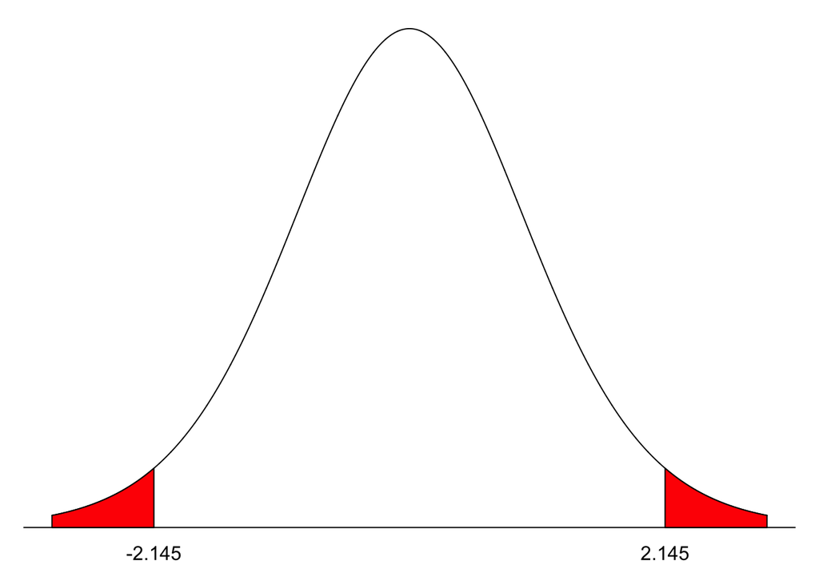

```r
alpha <- 0.05
ul <- qt(1-(alpha/2), df=14)
ll <- -ul


par(mar=c(0.5,1,1,1))
x <- seq(-3, 3, by=0.001)
y <- dt(x, df=14)
plot(x, y, type="l", axes=F, ylim=c(-0.02, 0.38), main="", xlab="t", ylab="")
abline(h=0)
polygon(c(-3, x[x<ll], ll), c(0, y[x<ll], 0), col=2)
#polygon(c(-3, ll), c(0, 0), col=2)

polygon(c(ul, x[x>ul], 3), c(0, y[x>ul], 0), col=2)
#text(-2.5, 0.1, expression(plain(P)(T<t) == 0.025), cex=0.7)
#text(2.5, 0.1, expression(plain(P)(T>t) == 0.025), cex=0.7)
text(ll, -0.02, round(ll,3))
text(ul, -0.02, round(ul,3))
```

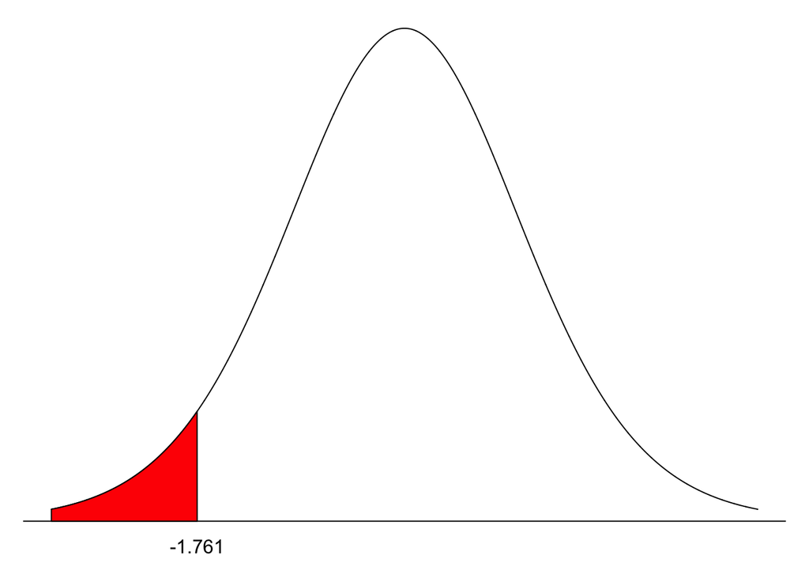

```r
alpha <- 0.05
u.s <- qt(1-(alpha), df=14)
l.s <- qt(alpha,df=14)


par(mar=c(0.5,1,1,1))
x <- seq(-3, 3, by=0.001)
y <- dt(x, df=14)
plot(x, y, type="l", axes=F, ylim=c(-0.02, 0.38), main="", xlab="t", ylab="")
abline(h=0)
polygon(c(-3, x[x<l.s], l.s), c(0, y[x<l.s], 0), col=2)
text(l.s, -0.02, round(l.s,3))
```

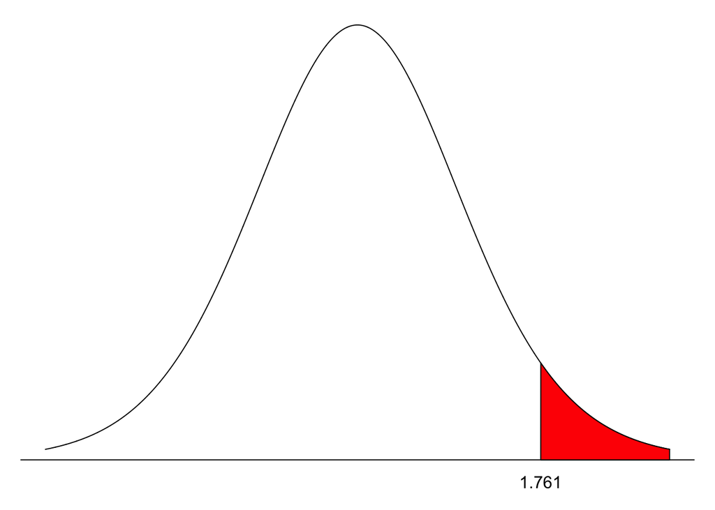

```r
par(mar=c(0.5,1,1,1))
plot(x, y, type="l", axes=F, ylim=c(-0.02, 0.38), main="", xlab="t", ylab="")
abline(h=0)
polygon(c(u.s, x[x>u.s], 3), c(0, y[x>u.s], 0), col=2)
text(u.s, -0.02, round(u.s,3))
```

## 가설검정

### 임계점과 기각역

- (귀무가설 하에서)검정통계량이 임계치보다 크거나 작으면 귀무가설 기각/ 검정통계량이 기각역 안에 있으면 귀무가설 기각

유의수준 5% 양측검정 시 귀무가설을 기각하지 못함

유의수준 5% 단축검정 시 귀무가설 기각 못함.

그럼 유의수준이 3% 면? 1% 면? 25%면?

```r
alpha <- 0.03
ul.3 <- qt(1-(alpha/2), df=14)
ll.3 <- -ul.3
print ("crit at sig level 3%: two-way")
```

```
## [1] "crit at sig level 3%: two-way"
```

```r
print (ul.3)
```

```
## [1] 2.414898
```

```r
print (ll.3)
```

```
## [1] -2.414898
```

```r
alpha <- 0.03
ul.3.1 <- qt(1-(alpha), df=14)
ll.3.1 <- -ul.3.1
print ("crit at sig level 3%: one-way")
```

```
## [1] "crit at sig level 3%: one-way"
```

```r
print (ul.3.1)
```

```
## [1] 2.046169
```

```r
print (ll.3.1)
```

```
## [1] -2.046169
```

```r
alpha <- 0.01
ul.1 <- qt(1-(alpha/2), df=14)
ll.1<- -ul.1
ll.1<- -ul.1
print ("crit at sig level 1%: two-way")
```

```
## [1] "crit at sig level 1%: two-way"
```

```r
print (ul.1)
```

```
## [1] 2.976843
```

```r
print (ll.1)
```

```
## [1] -2.976843
```

```r
alpha <- 0.01
ul.1.1 <- qt(1-(alpha), df=14)
ll.1.1 <- -ul.1.1
print ("crit at sig level 1%: one-way")
```

```
## [1] "crit at sig level 1%: one-way"
```

```r
print (ul.1.1)
```

```
## [1] 2.624494
```

```r
print (ll.1.1)
```

```
## [1] -2.624494
```

### p-value

```r
pv.T=1-pt(-T,df=(N-1))+pt(T,df=(N-1))
print ("Pvalue . Two way test")
```

```
## [1] "Pvalue . Two way test"
```

```r
print (pv.T)
```

```
## [1] 0.2088289
```

```r
print ("Ho reject at 5%?")
```

```
## [1] "Ho reject at 5%?"
```

```r
pv.T<0.05
```

```
## [1] FALSE
```

```r
print ("Ho reject at 3%?")
```

```
## [1] "Ho reject at 3%?"
```

```r
pv.T<0.03
```

```
## [1] FALSE
```

```r
print ("Ho reject at 1%?")
```

```
## [1] "Ho reject at 1%?"
```

```r
pv.T<0.01
```

```
## [1] FALSE
```

```r
pv.T.1=pt(T,df=(N-1))
print("Pvalue one way test(smaller)")
```

```
## [1] "Pvalue one way test(smaller)"
```

```r
print (pv.T.1)
```

```
## [1] 0.1044145
```

```r
print ("Ho reject at 5%?")
```

```
## [1] "Ho reject at 5%?"
```

```r
pv.T.1<0.05
```

```
## [1] FALSE
```

```r
print ("Ho reject at 3%?")
```

```
## [1] "Ho reject at 3%?"
```

```r
pv.T.1<0.03
```

```
## [1] FALSE
```

```r
print ("Ho reject at 1%?")
```

```
## [1] "Ho reject at 1%?"
```

```r
pv.T.1<0.01
```

```
## [1] FALSE
```

# 단일 모집단 가설검정

## 모집단 평균 가설검정: 여아 신생아 몸무게

1. 가설 수립

$$H_o:\mu=2800(g),\qquad .vs\qquad H_1:\mu > 2800$$

2. 검정 통계량 계산

3. 가설 채택 기준 설정: 유의수준 5% 오른쪽 한쪽검정

$$c_{\alpha,u}:\qquad P(T>c_{\alpha,u})=0.05 \rightarrow c_{\alpha, u}=$$

```r
qt(1-0.05,17)
```

```
## [1] 1.739607
```

4. 채택/기각 결정

$$T = 2.23 > 1.739607 \Rightarrow \quad \mbox{Reject } H_o$$
$$P(T>t) =$$

```r
1-pt(2.23,df=17)
```

```
## [1] 0.01975833
```

$$<0.05\Rightarrow \mbox{Reject } H_o$$

```r
#data <- read.table("http://www.amstat.org/publications/jse/datasets/babyboom.dat.txt", header=F)
load("weight.Rdata")
str( data )
```

```
## 'data.frame':    44 obs. of  4 variables:
##  $ V1: int  5 104 118 155 257 405 407 422 431 708 ...
##  $ V2: int  1 1 2 2 2 1 1 2 2 2 ...
##  $ V3: int  3837 3334 3554 3838 3625 2208 1745 2846 3166 3520 ...
##  $ V4: int  5 64 78 115 177 245 247 262 271 428 ...
```

```r
names(data) <- c("time", "gender", "weight", "minutes")
tmp <- subset(data, gender==1)
weight <- tmp[[3]]

barx <- mean(weight)
s <- sd(weight)
n <- length(weight)
h0 <- 2800
( t.t <- (barx - h0) / (s / sqrt(n)) )
```

```
## [1] 2.233188
```

```r
alpha <- 0.05
( c.u <- qt(1-alpha, df=n-1) )
```

```
## [1] 1.739607
```

```r
( p.value <- 1 - pt(t.t, df=n-1) )
```

```
## [1] 0.01963422
```

```r
t.test(weight, mu=2800, alternative="greater")
```

```
##
##  One Sample t-test
##
## data:  weight
## t = 2.2332, df = 17, p-value = 0.01963
## alternative hypothesis: true mean is greater than 2800
## 95 percent confidence interval:
##  2873.477      Inf
## sample estimates:
## mean of x
##  3132.444
```

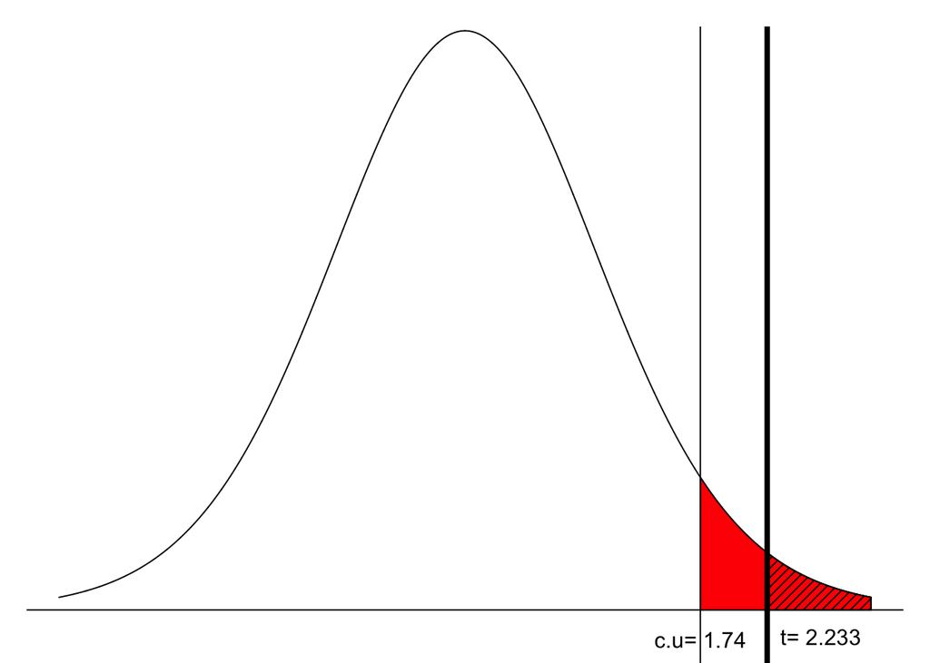

```r
# 도표 작성 : 그림 6-8
par(mar=c(0,1,1,1))
x <- seq(-3, 3, by=0.001)
y <- dt(x, df=n-1)
plot(x, y, type="l", axes=F, ylim=c(-0.02, 0.38), main="", xlab="t", ylab="")
abline(h=0)

polygon(c(c.u, x[x>c.u], 3), c(0, y[x>c.u], 0), col=2)
abline(v=c.u,lwd=1)
text(c.u, -0.02, paste("c.u=", round(c.u,3)))
abline(v=t.t,lwd=4)
polygon(c(t.t, x[x>t.t], 3), c(0, y[x>t.t], 0), density=20, angle=45)
text(t.t, -0.02, paste("t=", round(t.t, 3)), pos=4)
```

## 모집단 비율 가설검정: 야구공 불량률

1. 가설 수립

$$H_o:p=0.1\qquad .vs\qquad H_1:p > 0.1$$

2. 검정 통계량 계산

$$H_o: Z =\frac{\hat{p}-p}{\sqrt{\frac{\hat{p}(1-\hat{p})}{N}}}\sim N(0,1)$$
$$\hat{p}=X/n =\sum(Z_i)/N\quad Z_i \sim b(p),\qquad \hat{p}=\bar{Z}\sim N(p,p(1-p)/N)$$

$$Z =\frac{\hat{p}-p}{\sqrt{\frac{p\times (1-p)}{N}}}=\frac{\hat{p}-0.1}{\sqrt{\frac{0.1\times (1-0.1)}{100}}}=0.333$$

3. 가설 채택 기준 설정: 유의수준 5% 오른쪽 한쪽검정

$$c_{\alpha,u}:\qquad P(Z>c_{\alpha,u})=0.05 \rightarrow c_{\alpha, u}=$$

```r
qnorm(1-0.05)
```

```
## [1] 1.644854
```

4. 채택/기각 결정

$$Z = 0.33 < 1.644854 \Rightarrow \quad \mbox{Not Reject } H_o$$

$$P(Z>0.33) =$$

```r
1-pnorm(0.33)
```

```
## [1] 0.3707
```

$$> 0.05\Rightarrow \mbox{Not Reject } H_o$$

```r
tmp <- read.table("./data/restitution.txt", header=T)
rel <- ifelse(tmp$rst < 0.4134 | tmp$rst > 0.4374, 1, 0)

n <- length(rel)
nos <- sum(rel)
sp <- nos / n
hp <- 0.1
(z <- (sp - hp) / sqrt( ( sp*(1-sp) )/n ) )
```

```
## [1] 0.3196014
```

```r
alpha <- 0.05
( c.u <- qnorm(1-alpha) )
```

```
## [1] 1.644854
```

```r
( p.value <- 1 - pnorm(z) )
```

```
## [1] 0.3746353
```

```r
prop.test(nos, n, p=0.1, alternative="greater", correct=FALSE)
```

```
##
##  1-sample proportions test without continuity correction
##
## data:  nos out of n, null probability 0.1
## X-squared = 0.11111, df = 1, p-value = 0.3694
## alternative hypothesis: true p is greater than 0.1
## 95 percent confidence interval:
##  0.0684615 1.0000000
## sample estimates:
##    p
## 0.11
```

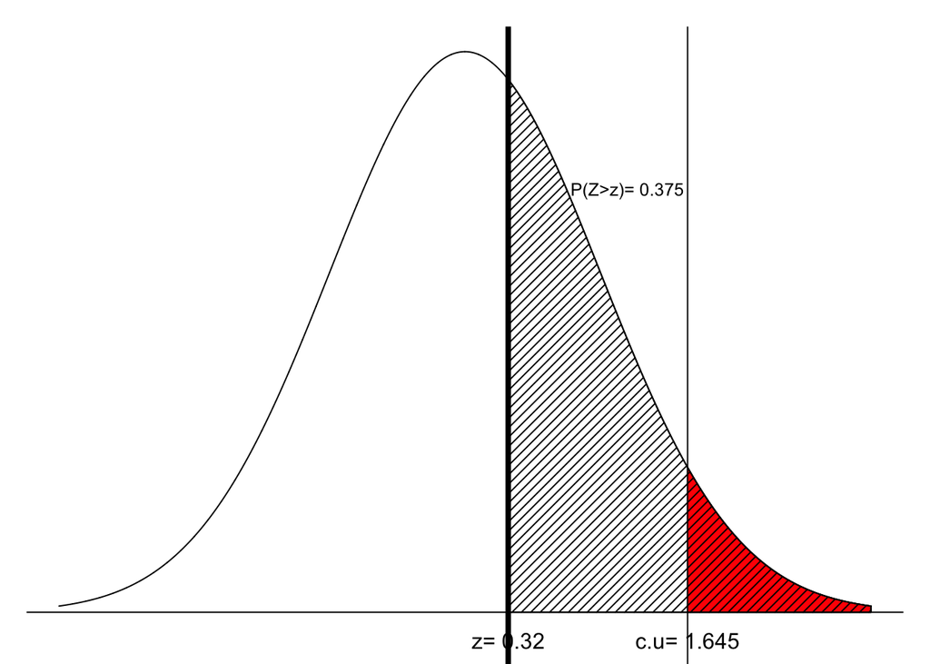

```r
# 도표 출력 : 그림 6-9
par(mar=c(0,1,1,1))
x <- seq(-3, 3, by=0.001)
y <- dnorm(x)
plot(x, y, type="l", axes=F, ylim=c(-0.02, 0.4), main="", xlab="z", ylab="")
abline(h=0)
abline(v=c.u,lwd=1)
abline(v=z,lwd=4)
text(c.u, -0.02, paste("c.u=", round(c.u,3)))
text(z, -0.02, paste("z=", round(z, 3)))

polygon(c(c.u, x[x>c.u], 3), c(0, y[x>c.u], 0), col=2)
polygon(c(z, x[x>z], 3), c(0, y[x>z], 0), density=20, angle=45)
text(1.2, 0.3, paste("P(Z>z)=", round(p.value, 3)), cex=0.8)
```